# MERDs Bacterial Community Analyses

Lukas Bell-Dereske

9/1/2020

Here is the Code for analyzing the bacterial community composition of MERDS Switchgrass Experiment Lukas (belldere@msu.edu) processed the sequences and subset the larger run to only have samples from MERDS (MERDs 56 of 317 samples in the run)

# Begin OTU based community

## Change from initial soil community

#### Transplant Experimental Distance from start community seedling

##### Graph for publication

```
## [1] 24
```

```
## [1] G
## Levels: G S Start
```

```
## [1] L.R S.B L.B
## Levels: L.B S.B L.R
```

```
## [1] A D
## Levels: A D Start
```

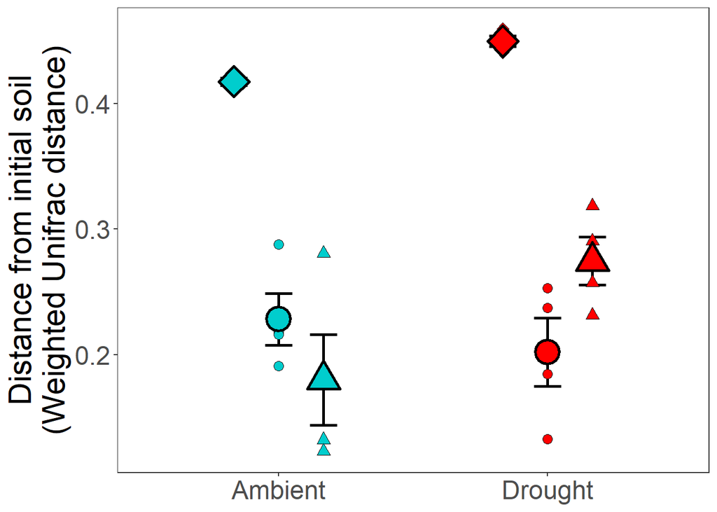

#### Presence Distance from start community seedling Diagnostic Graphs

```r
SILVA_MERDS_rar_WU_dis_wi_bl_trans_pres=subset(SILVA_MERDS_rar_WU_dis_start_wi_bl_trans_exp,time!="Start"&s1_soil_root!="L.R")

nrow(SILVA_MERDS_rar_WU_dis_wi_bl_trans_pres)
```

```
## [1] 16
```

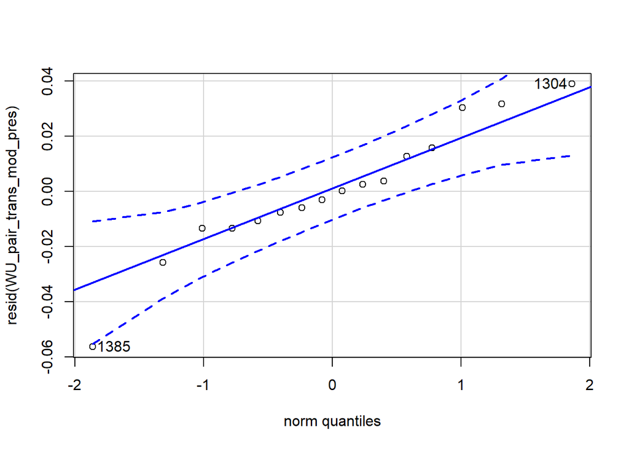

```
## 1385 1304
##   14    6
```

```r
#16


WU_pair_trans_mod_pres= lmer(w_unifrac~s1_soil_root*s1_precip+(1|sample2), data= SILVA_MERDS_rar_WU_dis_wi_bl_trans_pres)
qqPlot(resid(WU_pair_trans_mod_pres))
```

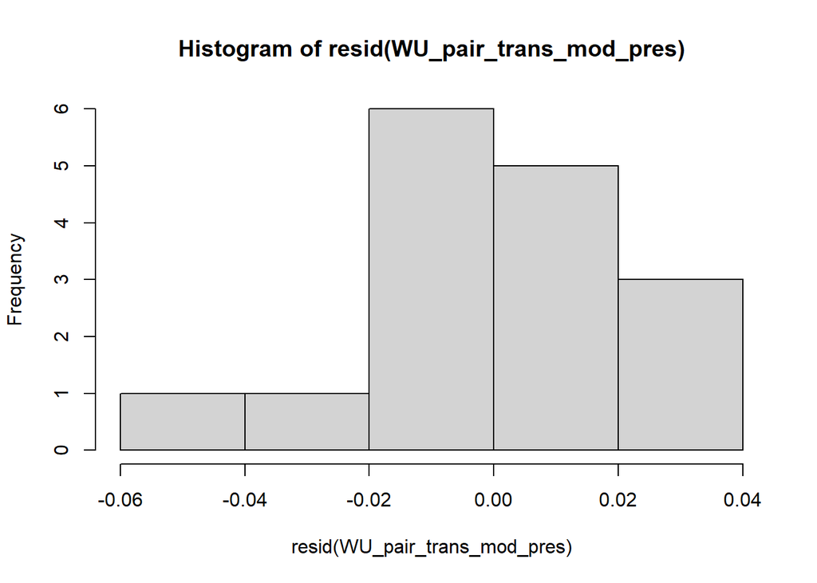

```r
hist(resid(WU_pair_trans_mod_pres))
```

```r
shapiro.test(resid(WU_pair_trans_mod_pres))
```

```
##
##  Shapiro-Wilk normality test
##
## data:  resid(WU_pair_trans_mod_pres)
## W = 0.95278, p-value = 0.535
```

```r
#0.535
```

Raw Statistical output

```r
anova(WU_pair_trans_mod_pres, type=3)
```

```
## Type III Analysis of Variance Table with Satterthwaite's method
##                          Sum Sq  Mean Sq NumDF DenDF  F value    Pr(>F)
## s1_soil_root           0.190650 0.190650     1     9 231.0966 1.004e-07 ***
## s1_precip              0.000034 0.000034     1     9   0.0416   0.84284
## s1_soil_root:s1_precip 0.003398 0.003398     1     9   4.1193   0.07298 .
## ---
## Signif. codes:  0 '***' 0.001 '**' 0.01 '*' 0.05 '.' 0.1 ' ' 1
```

```r
emmeans(WU_pair_trans_mod_pres, pairwise~s1_soil_root|s1_precip)
```

```
## $emmeans
## s1_precip = A:
##  s1_soil_root emmean     SE  df lower.CL upper.CL
##  L.B           0.228 0.0173 9.3    0.189    0.267
##  S.B           0.417 0.0173 9.3    0.378    0.456
##
## s1_precip = D:
##  s1_soil_root emmean     SE  df lower.CL upper.CL
##  L.B           0.202 0.0173 9.3    0.163    0.241
##  S.B           0.450 0.0173 9.3    0.411    0.488
##
## Degrees-of-freedom method: kenward-roger
## Confidence level used: 0.95
##
## $contrasts
## s1_precip = A:
##  contrast  estimate     SE df t.ratio p.value
##  L.B - S.B   -0.189 0.0203  9  -9.314 <.0001
##
## s1_precip = D:
##  contrast  estimate     SE df t.ratio p.value
##  L.B - S.B   -0.247 0.0203  9 -12.184 <.0001
##
## Degrees-of-freedom method: kenward-roger
```

Formatted Anova table

Trans Distance to initial soil communtiy

|  | Df | Resid.Df | F.value | P.value |
| --- | --- | --- | --- | --- |
| s1_soil_root | 1 | 9 | 231.10 | 0.000 |
| s1_precip | 1 | 9 | 0.04 | 0.843 |
| s1_soil_root:s1_precip | 1 | 9 | 4.12 | 0.073 |

#### Origin Distance from start community seedling

##### Graph for publication

```
## [1] 16
```

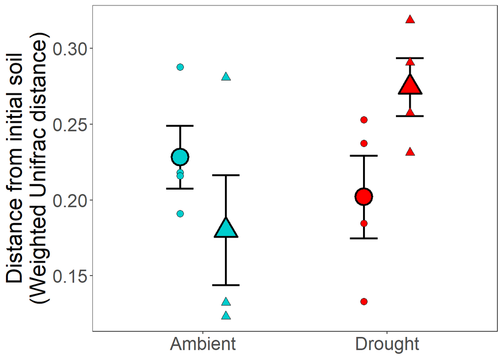

#### Origin Distance from start community seedling

Diagnostic Graphs

```r
SILVA_MERDS_rar_WU_dis_wi_bl_trans=subset(SILVA_MERDS_rar_WU_dis_start_wi_bl_trans,time!="Start")

nrow(SILVA_MERDS_rar_WU_dis_wi_bl_trans)
```

```
## [1] 16
```

```r
#16


WU_pair_trans_mod= lmer(w_unifrac~s1_soil_root*s1_precip+(1|sample2), data= SILVA_MERDS_rar_WU_dis_wi_bl_trans)
```

```
## boundary (singular) fit: see ?isSingular
```

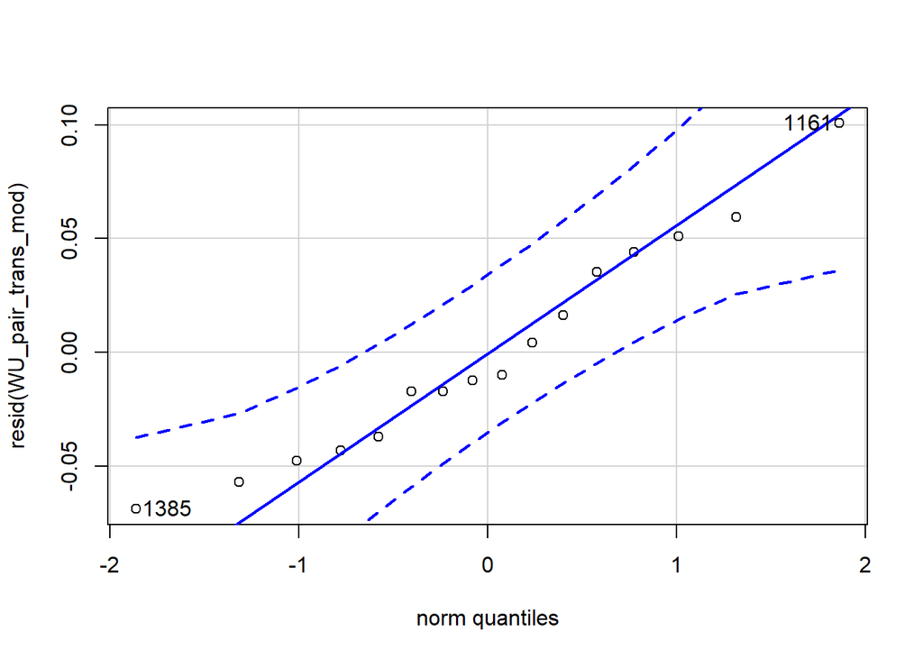

```
## 1161 1385
##    3   13
```

```r
qqPlot(resid(WU_pair_trans_mod))
```

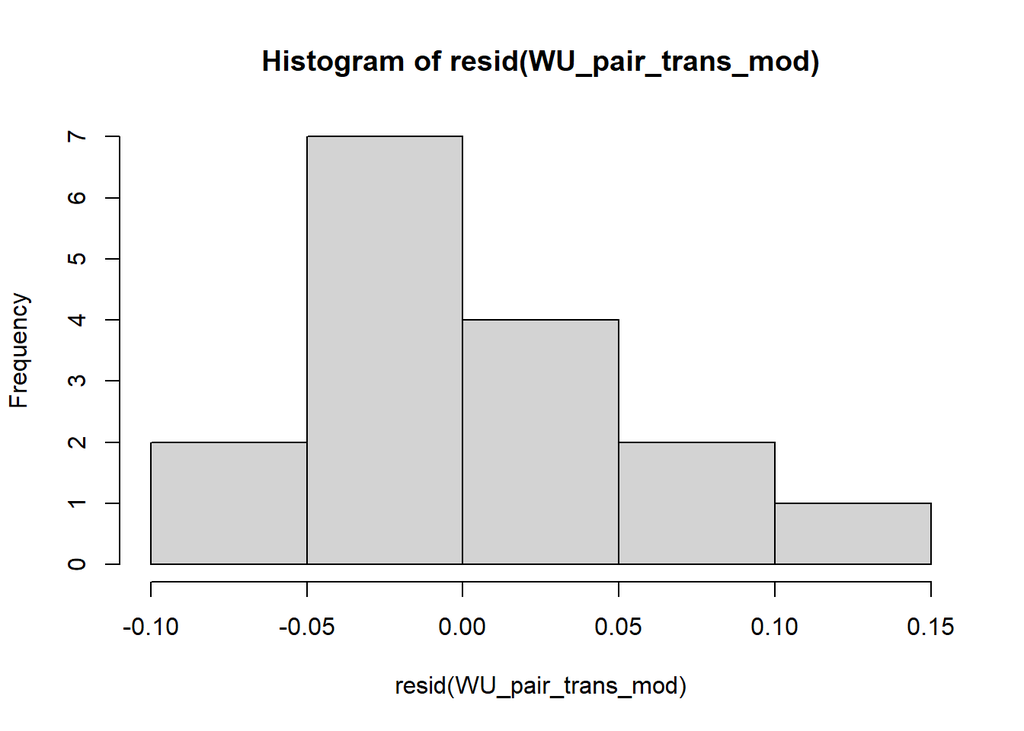

```r
hist(resid(WU_pair_trans_mod))
```

```r
shapiro.test(resid(WU_pair_trans_mod))
```

```
##
##  Shapiro-Wilk normality test
##
## data:  resid(WU_pair_trans_mod)
## W = 0.96081, p-value = 0.6766
```

```r
# 0.6766
```

Raw Statistical output

```r
anova(WU_pair_trans_mod, type=3)
```

```
## Type III Analysis of Variance Table with Satterthwaite's method
##                           Sum Sq   Mean Sq NumDF DenDF F value  Pr(>F)
## s1_soil_root           0.0005971 0.0005971     1    12  0.2102 0.65480
## s1_precip              0.0046420 0.0046420     1    12  1.6342 0.22530
## s1_soil_root:s1_precip 0.0145361 0.0145361     1    12  5.1174 0.04304 *
## ---
## Signif. codes:  0 '***' 0.001 '**' 0.01 '*' 0.05 '.' 0.1 ' ' 1
```

```r
emmeans(WU_pair_trans_mod, pairwise~s1_soil_root|s1_precip)
```

```
## $emmeans
## s1_precip = A:
##  s1_soil_root emmean     SE df lower.CL upper.CL
##  L.B           0.228 0.0266 12    0.170    0.286
##  L.R           0.180 0.0266 12    0.122    0.238
##
## s1_precip = D:
##  s1_soil_root emmean     SE df lower.CL upper.CL
##  L.B           0.202 0.0266 12    0.144    0.260
##  L.R           0.275 0.0266 12    0.216    0.333
##
## Degrees-of-freedom method: kenward-roger
## Confidence level used: 0.95
##
## $contrasts
## s1_precip = A:
##  contrast  estimate     SE df t.ratio p.value
##  L.B - L.R   0.0481 0.0377 12  1.275  0.2263
##
## s1_precip = D:
##  contrast  estimate     SE df t.ratio p.value
##  L.B - L.R  -0.0725 0.0377 12 -1.924  0.0784
##
## Degrees-of-freedom method: kenward-roger
```

Formatted Anova table

Trans Distance to initial soil communtiy

|  | Df | Resid.Df | F.value | P.value |
| --- | --- | --- | --- | --- |
| s1_soil_root | 1 | 12 | 0.21 | 0.655 |
| s1_precip | 1 | 12 | 1.63 | 0.225 |
| s1_soil_root:s1_precip | 1 | 12 | 5.12 | 0.043 |

#### Seed Experimental Distance from start community seedling

##### Graph for publication

```
## [1] 23
```

```
## [1] L.R L.B S.B
## Levels: L.B S.B L.R
```

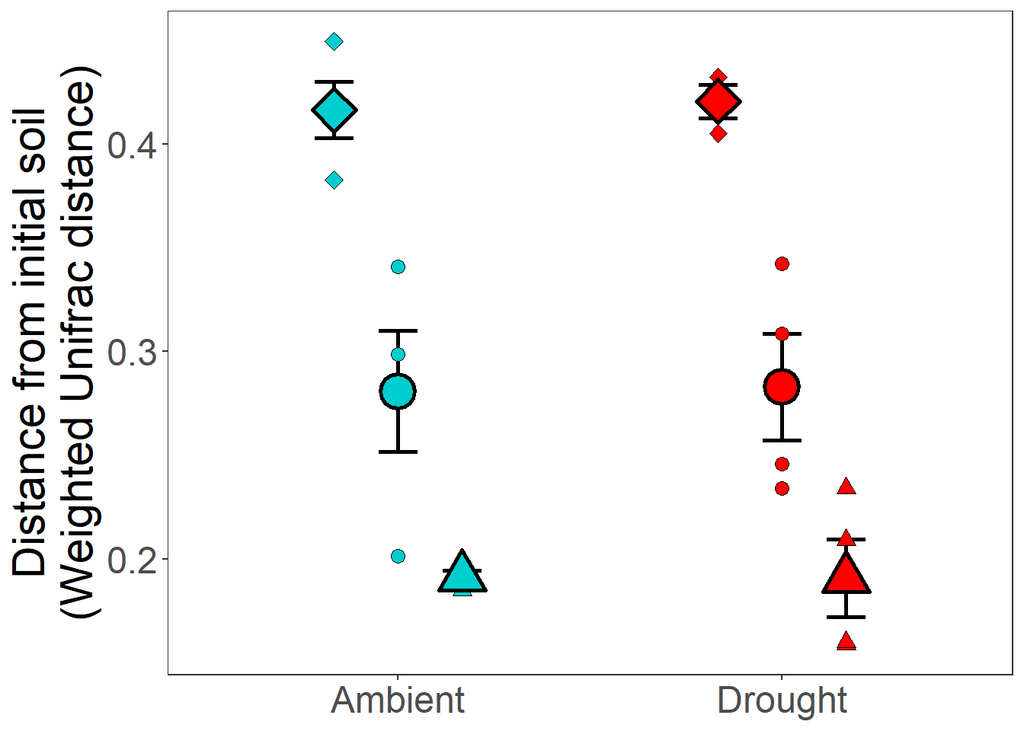

#### Presence Distance from start community seedling

Diagnostic Graphs

```r
SILVA_MERDS_rar_WU_dis_wi_bl_seed_pres=subset(SILVA_MERDS_rar_WU_dis_start_wi_bl_seed_exp,time!="Start"&s1_soil_root!="L.R")
nrow(SILVA_MERDS_rar_WU_dis_wi_bl_seed_pres)
```

```
## [1] 15
```

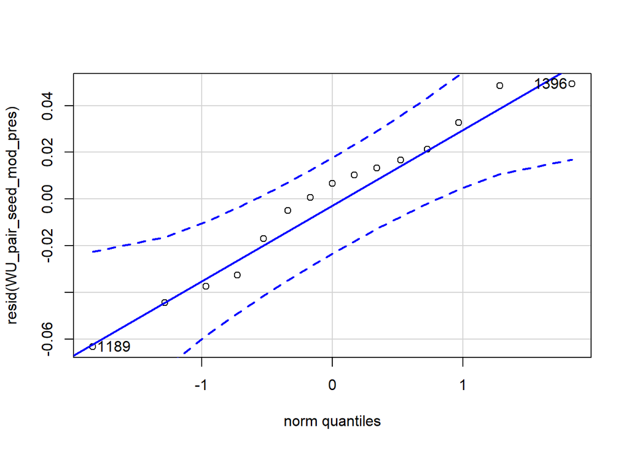

```
## 1189 1396
##    2   14
```

```r
#15
WU_pair_seed_mod_pres= lmer(w_unifrac~s1_soil_root*s1_precip+(1|sample2), data= SILVA_MERDS_rar_WU_dis_wi_bl_seed_pres)
qqPlot(resid(WU_pair_seed_mod_pres))
```

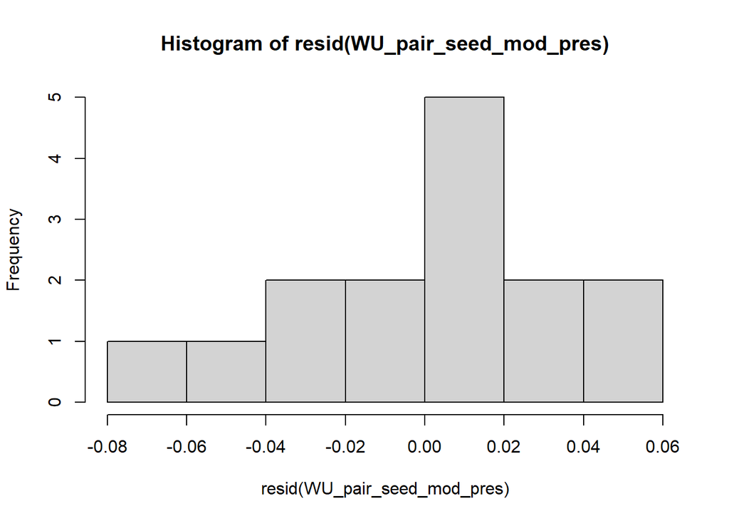

```r
hist(resid(WU_pair_seed_mod_pres))
```

```r
shapiro.test(resid(WU_pair_seed_mod_pres))
```

```
##
##  Shapiro-Wilk normality test
##
## data:  resid(WU_pair_seed_mod_pres)
## W = 0.96396, p-value = 0.7608
```

Raw Statistical output

```r
anova(WU_pair_seed_mod_pres)
```

```
## Type III Analysis of Variance Table with Satterthwaite's method
##                          Sum Sq  Mean Sq NumDF  DenDF F value    Pr(>F)
## s1_soil_root           0.065142 0.065142     1 8.3692 40.6645 0.0001766 ***
## s1_precip              0.000008 0.000008     1 8.3692  0.0048 0.9466099
## s1_soil_root:s1_precip 0.000001 0.000001     1 8.3692  0.0006 0.9815586
## ---
## Signif. codes:  0 '***' 0.001 '**' 0.01 '*' 0.05 '.' 0.1 ' ' 1
```

Formatted Anova table

Seed Distance to initial soil communtiy

|  | Df | Resid.Df | F.value | P.value |
| --- | --- | --- | --- | --- |
| s1_soil_root | 1 | 8.37 | 40.66 | 0.000 |
| s1_precip | 1 | 8.37 | 0.00 | 0.947 |
| s1_soil_root:s1_precip | 1 | 8.37 | 0.00 | 0.982 |

#### Origin Distance from start community seedling

##### Graph for publication

```
## [1] 16
```

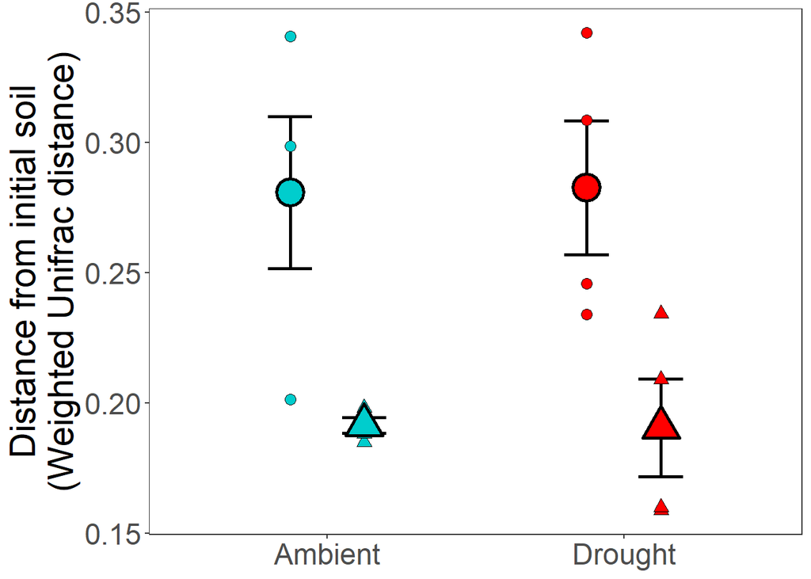

Diagnostic Graphs

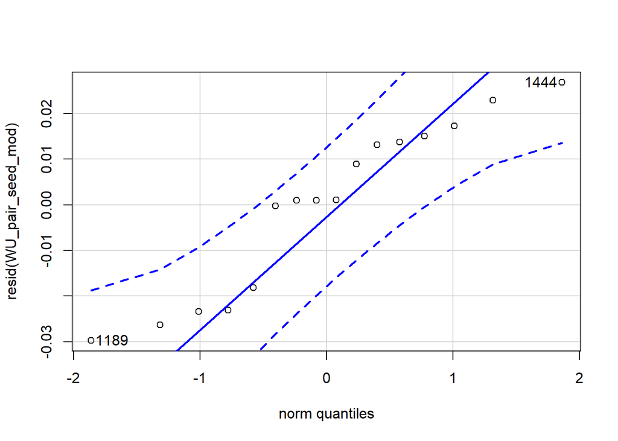

```
## 1189 1444
##    5   15
```

```r
SILVA_MERDS_rar_WU_dis_wi_bl_seed=subset(SILVA_MERDS_rar_WU_dis_start_wi_bl_seed,time!="Start")

WU_pair_seed_mod= lmer(w_unifrac~s1_soil_root*s1_precip+(1|sample2), data= SILVA_MERDS_rar_WU_dis_wi_bl_seed)
qqPlot(resid(WU_pair_seed_mod))
```

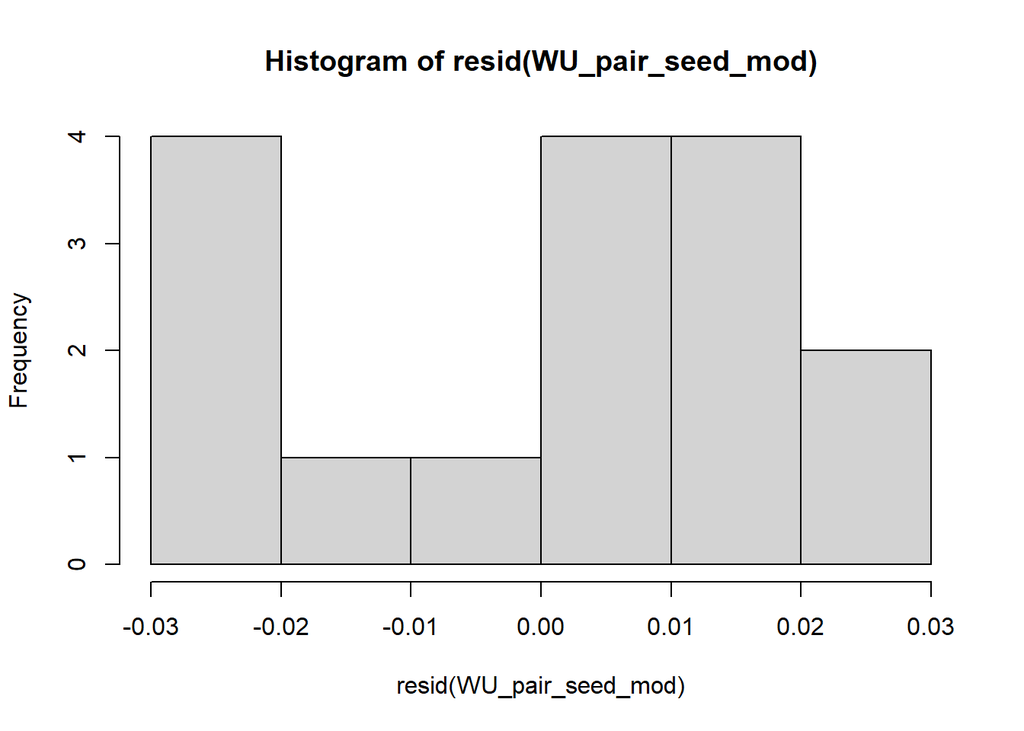

```r
hist(resid(WU_pair_seed_mod))
```

```r
shapiro.test(resid(WU_pair_seed_mod))
```

```
##
##  Shapiro-Wilk normality test
##
## data:  resid(WU_pair_seed_mod)
## W = 0.91232, p-value = 0.1268
```

Raw Statistical output

```r
anova(WU_pair_seed_mod)
```

```
## Type III Analysis of Variance Table with Satterthwaite's method
##                           Sum Sq   Mean Sq NumDF  DenDF F value  Pr(>F)
## s1_soil_root           0.0071116 0.0071116     1 6.0651 10.2120 0.01843 *
## s1_precip              0.0000088 0.0000088     1 6.5707  0.0127 0.91378
## s1_soil_root:s1_precip 0.0000007 0.0000007     1 6.5707  0.0010 0.97556
## ---
## Signif. codes:  0 '***' 0.001 '**' 0.01 '*' 0.05 '.' 0.1 ' ' 1
```

Formatted Anova table

Seed Distance to initial soil communtiy

|  | Df | Resid.Df | F.value | P.value |
| --- | --- | --- | --- | --- |
| s1_soil_root | 1 | 6.07 | 10.21 | 0.018 |
| s1_precip | 1 | 6.57 | 0.01 | 0.914 |
| s1_soil_root:s1_precip | 1 | 6.57 | 0.00 | 0.976 |

### Community Analyses both life stages

File creation for the analysis in Primer

```r
#####Weighted Unifrac####
SILVA_MERDS_rar_NS=subset_samples(SILVA_MERDS_rar, life_stage!="Start")
nsamples(SILVA_MERDS_rar_NS)
```

```
## [1] 47
```

```r
#47
SILVA_MERDS_rar_NS_WU_ord=ordinate(SILVA_MERDS_rar_NS, method = "NMDS", distance = "wunifrac")
```

```
## *** Solution reached
```

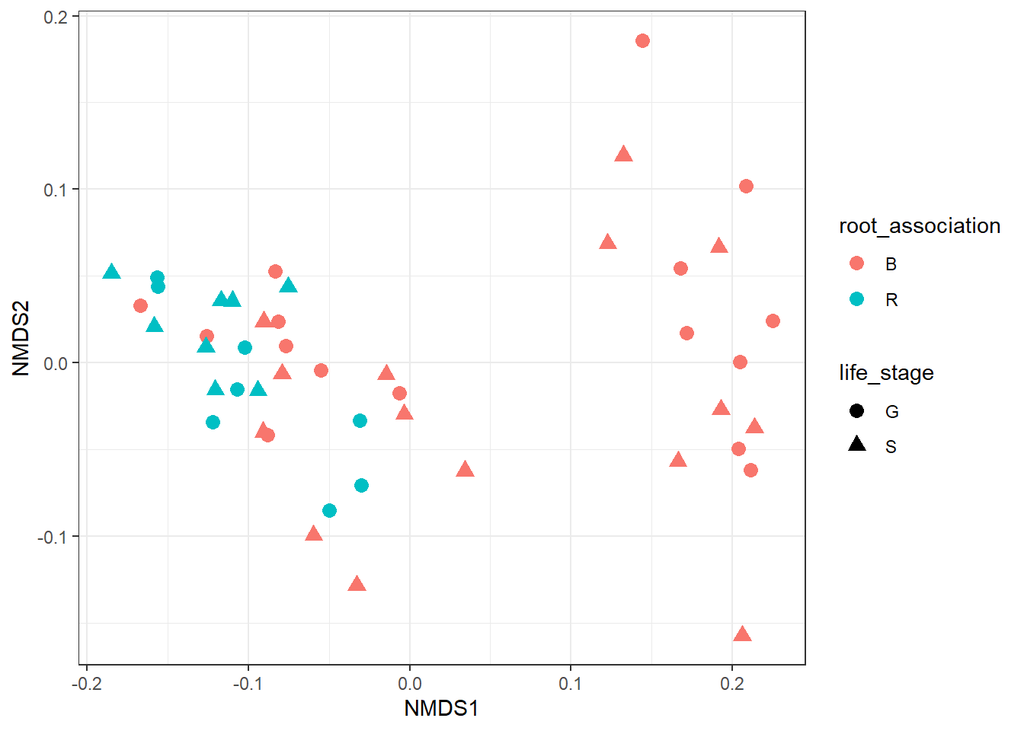

```r
#*** Solution reached
#0.08503251
plot_ordination(SILVA_MERDS_rar_NS,SILVA_MERDS_rar_NS_WU_ord, color="root_association",shape="life_stage")+geom_point(size=3)+
  theme_bw()
```

```r
#Treatment factors
#write.csv(data.frame(sample_data(SILVA_MERDS_rar_NS))[c("precip","block","soil_root","root_association","soil_status","life_stage")],"D:/MERDS_2018/merds/Switchgrass/R_data/SILVA_MERDS_rar_NS_map.csv")
#distance file
#write.csv(as.matrix(distance(SILVA_MERDS_rar_NS,method = "wunifrac")),"D:/MERDS_2018/merds/Switchgrass/R_data/Weight_Uni_SILVA_MERDS_rar_NS_dist.csv")
```

### Community Analyses Transplants

##### Graph for publication

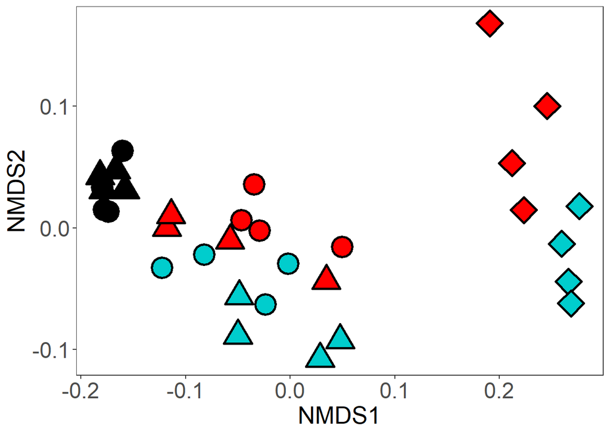

### Community Analyses Live Transplants

##### Graph for publication

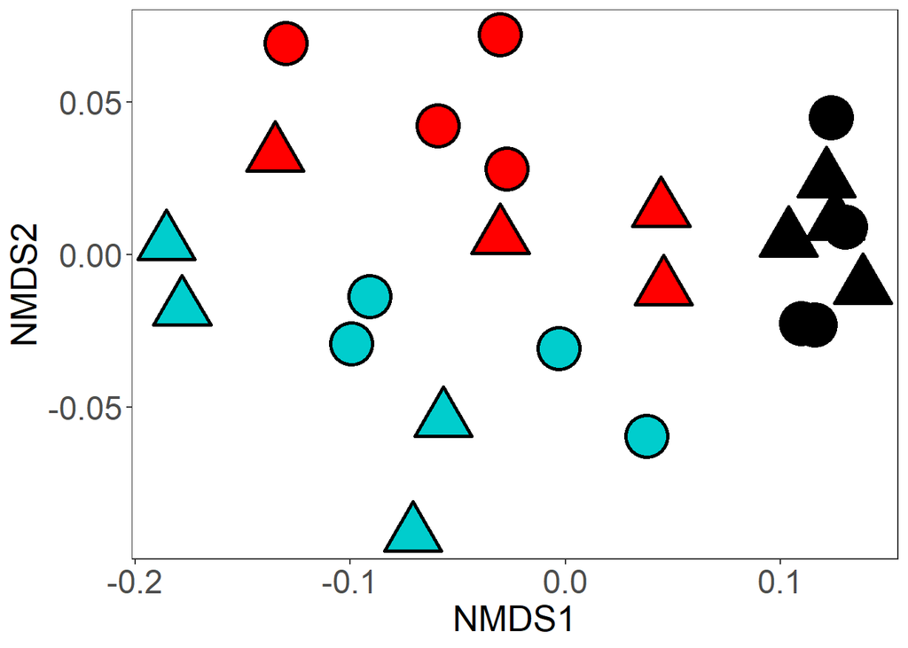

### Community Analyses Transplants with no Start

##### Graph for publication

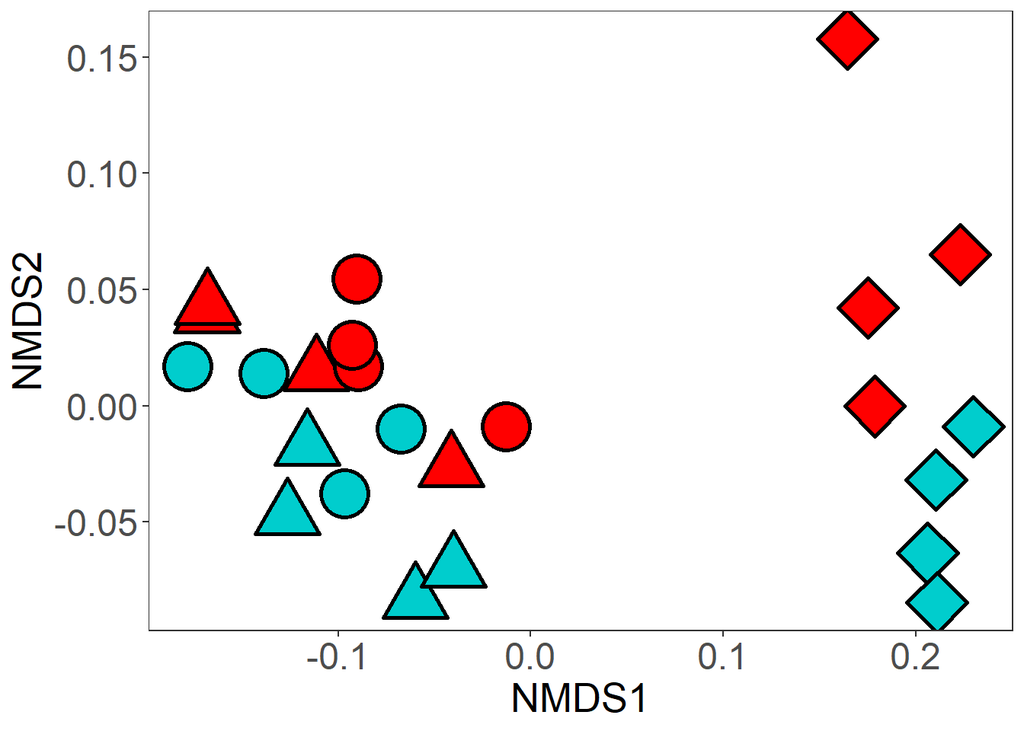

### Community Analyses Transplants with no Start

File creation for analyses in Primer

### Community Analyses Germination

##### Graph for publication

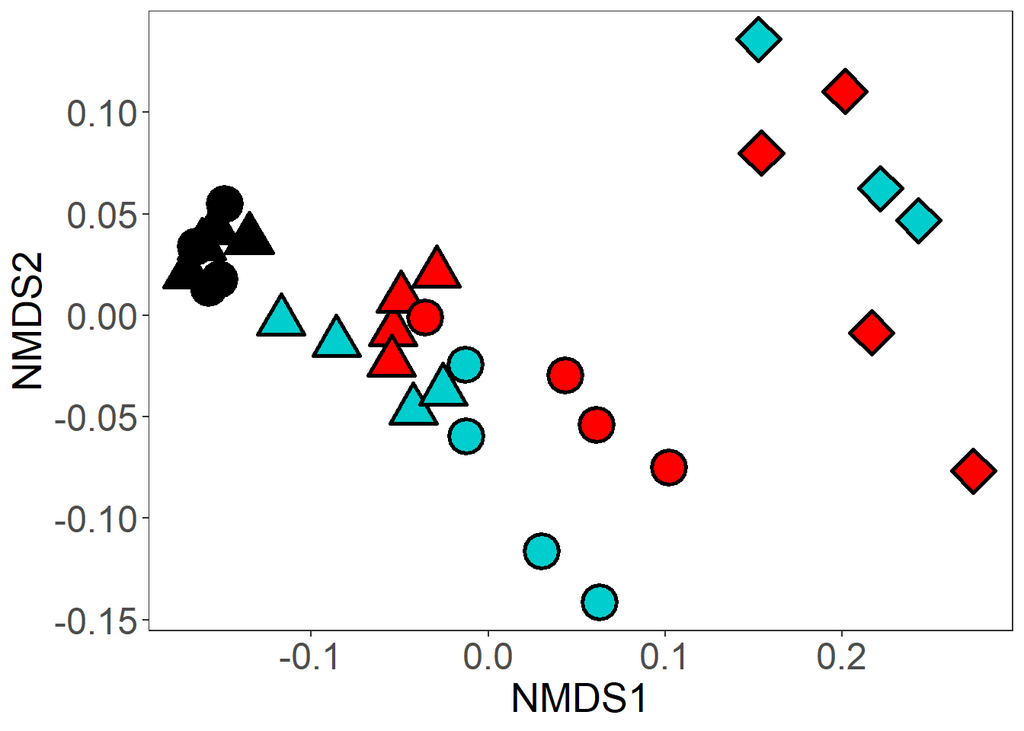

### Community Analyses Live Germination

##### Graph for publication

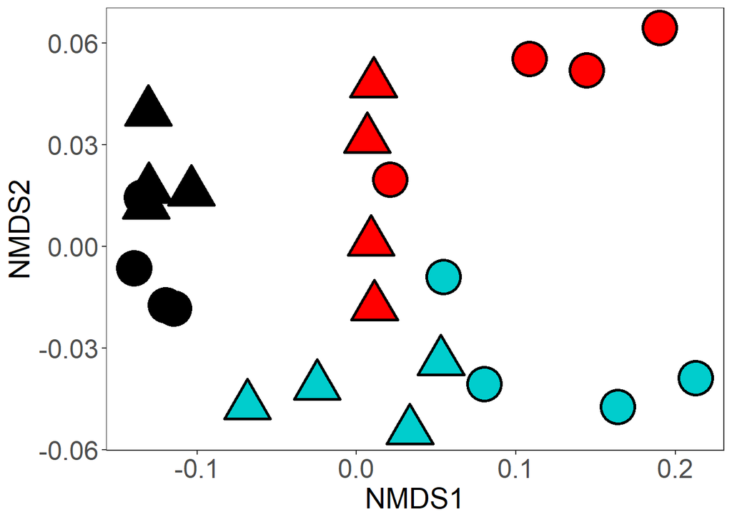

### Community Analyses Germination with no Start

##### Graph for publication

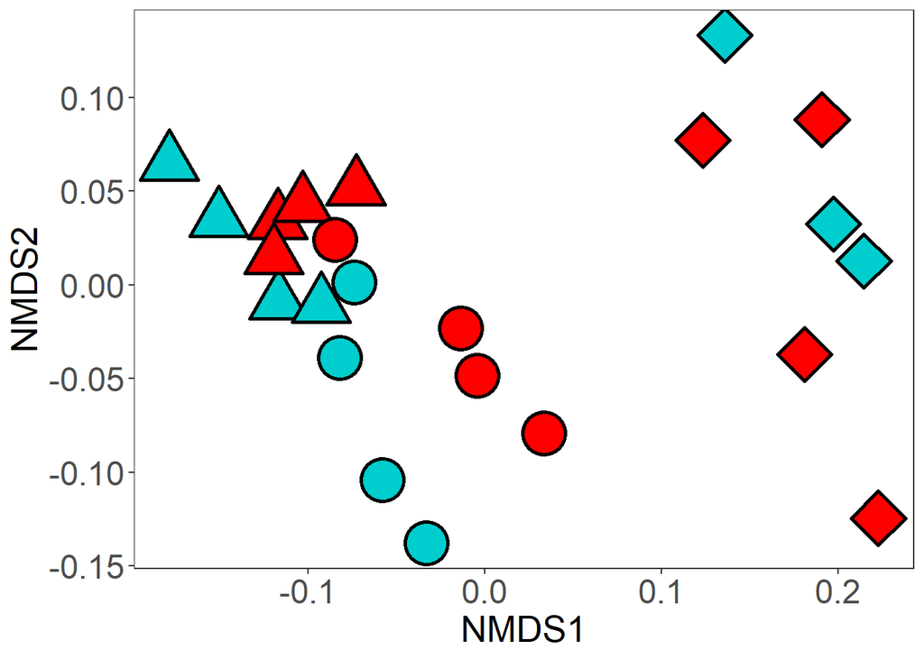

### Community Analyses Germination with no Start

File creation for analyses in Primer

### Transplant Stack bar graphs

```
## [1] 24
```

```
## [1] 8366
```

```
## [1] "L.B.A" "S.B.A" "L.R.A" "L.B.D" "S.B.D" "L.R.D"
```

```
##  [1] "p:Deinococcus-Thermus"      "p:TM6"
##  [3] "UNKNOWN"                    "p:Acidobacteria"
##  [5] "p:Elusimicrobia"            "p:Parcubacteria"
##  [7] "p:Proteobacteria"           "p:Microgenomates"
##  [9] "p:Candidate_division_SR1"   "p:SM2F11"
## [11] "p:Gracilibacteria"          "p:WCHB1-60"
## [13] "p:Saccharibacteria"         "p:Euryarchaeota"
## [15] "p:Thaumarchaeota"           "p:Woesearchaeota_[DHVEG-6]"
## [17] "p:Omnitrophica"             "p:Cyanobacteria"
## [19] "p:Spirochaetae"             "p:Chlorobi"
## [21] "p:GOUTA4"                   "p:Bacteroidetes"
## [23] "p:Planctomycetes"           "p:Armatimonadetes"
## [25] "p:Fibrobacteres"            "p:Chloroflexi"
## [27] "p:SHA-109"                  "p:Thermotogae"
## [29] "p:Firmicutes"               "p:Tenericutes"
## [31] "p:Actinobacteria"           "p:WD272"
## [33] "p:Aerophobetes"             "p:GAL08"
## [35] "p:Latescibacteria"          "p:Nitrospirae"
## [37] "p:Candidate_division_OP3"   "p:Verrucomicrobia"
## [39] "p:Hydrogenedentes"          "p:Chlamydiae"
## [41] "p:Lentisphaerae"            "p:JL-ETNP-Z39"
## [43] "p:Gemmatimonadetes"
```

```
## phyloseq-class experiment-level object
## otu_table()   OTU Table:         [ 44 taxa and 6 samples ]
## sample_data() Sample Data:       [ 6 samples by 42 sample variables ]
## tax_table()   Taxonomy Table:    [ 44 taxa by 7 taxonomic ranks ]
## phy_tree()    Phylogenetic Tree: [ 44 tips and 43 internal nodes ]
```

```
##      L.B.A             S.B.A              L.R.A             L.B.D
##  Min.   :0.01085   Min.   :0.000250   Min.   :0.01075   Min.   :0.008125
##  1st Qu.:0.02134   1st Qu.:0.002838   1st Qu.:0.02950   1st Qu.:0.025200
##  Median :0.03973   Median :0.022425   Median :0.04285   Median :0.032475
##  Mean   :0.09091   Mean   :0.090909   Mean   :0.09091   Mean   :0.090909
##  3rd Qu.:0.06989   3rd Qu.:0.047762   3rd Qu.:0.07831   3rd Qu.:0.088975
##  Max.   :0.56235   Max.   :0.687650   Max.   :0.48518   Max.   :0.498475
##      S.B.D              L.R.D
##  Min.   :0.000425   Min.   :0.005475
##  1st Qu.:0.001825   1st Qu.:0.018437
##  Median :0.002550   Median :0.022450
##  Mean   :0.090909   Mean   :0.090909
##  3rd Qu.:0.029413   3rd Qu.:0.063613
##  Max.   :0.785525   Max.   :0.626300
```

```
##      L.B.A             S.B.A              L.R.A             L.B.D
##  Min.   :0.01085   Min.   :0.000250   Min.   :0.01075   Min.   :0.008125
##  1st Qu.:0.02134   1st Qu.:0.002838   1st Qu.:0.02950   1st Qu.:0.025200
##  Median :0.03973   Median :0.022425   Median :0.04285   Median :0.032475
##  Mean   :0.09091   Mean   :0.090909   Mean   :0.09091   Mean   :0.090909
##  3rd Qu.:0.06989   3rd Qu.:0.047762   3rd Qu.:0.07831   3rd Qu.:0.088975
##  Max.   :0.56235   Max.   :0.687650   Max.   :0.48518   Max.   :0.498475
##      S.B.D              L.R.D             Phylum
##  Min.   :0.000425   Min.   :0.005475   Length:11
##  1st Qu.:0.001825   1st Qu.:0.018437   Class :character
##  Median :0.002550   Median :0.022450   Mode  :character
##  Mean   :0.090909   Mean   :0.090909
##  3rd Qu.:0.029413   3rd Qu.:0.063613
##  Max.   :0.785525   Max.   :0.626300
```

```
##     Phylum           variable      value
##  Length:66          L.B.A:11   Min.   :0.00025
##  Class :character   S.B.A:11   1st Qu.:0.01239
##  Mode  :character   L.R.A:11   Median :0.02686
##                     L.B.D:11   Mean   :0.09091
##                     S.B.D:11   3rd Qu.:0.06125
##                     L.R.D:11   Max.   :0.78553
```

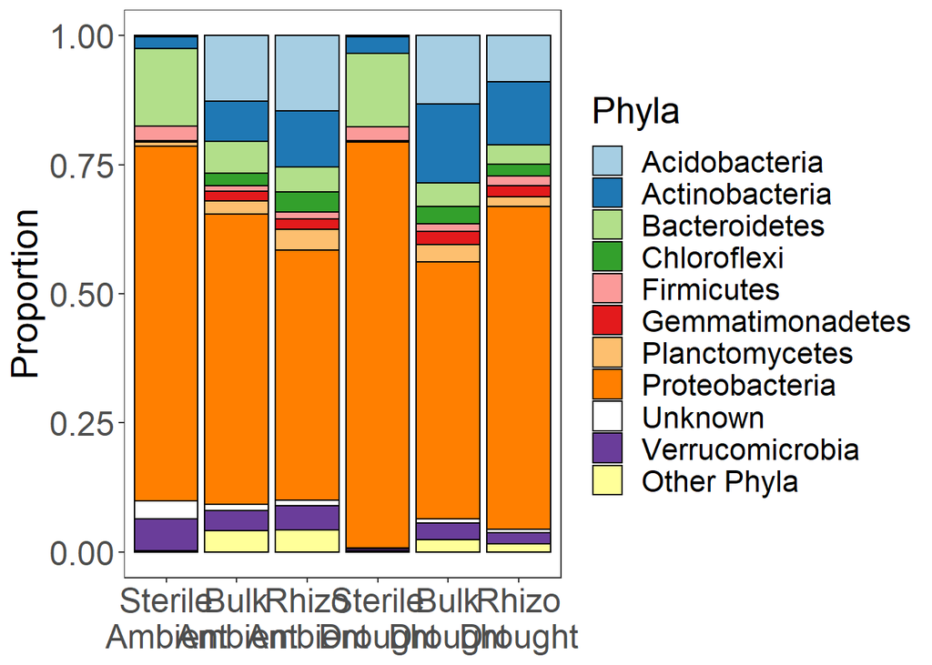

```
##  [1] "#A6CEE3" "#1F78B4" "#B2DF8A" "#33A02C" "#FB9A99" "#E31A1C" "#FDBF6F"
##  [8] "#FF7F00" "#CAB2D6" "#6A3D9A" "#FFFF99" "#B15928"
```

### Seed Stack bar graphs

```
## [1] 23
```

```
## [1] 8366
```

```
## [1] "L.B.A" "S.B.A" "L.R.A" "L.B.D" "S.B.D" "L.R.D"
```

```
##  [1] "p:Deinococcus-Thermus"      "p:TM6"
##  [3] "UNKNOWN"                    "p:Acidobacteria"
##  [5] "p:Elusimicrobia"            "p:Parcubacteria"
##  [7] "p:Proteobacteria"           "p:Microgenomates"
##  [9] "p:Candidate_division_SR1"   "p:SM2F11"
## [11] "p:Gracilibacteria"          "p:WCHB1-60"
## [13] "p:Saccharibacteria"         "p:Euryarchaeota"
## [15] "p:Thaumarchaeota"           "p:Woesearchaeota_[DHVEG-6]"
## [17] "p:Omnitrophica"             "p:Cyanobacteria"
## [19] "p:Spirochaetae"             "p:Chlorobi"
## [21] "p:GOUTA4"                   "p:Bacteroidetes"
## [23] "p:Planctomycetes"           "p:Armatimonadetes"
## [25] "p:Fibrobacteres"            "p:Chloroflexi"
## [27] "p:SHA-109"                  "p:Thermotogae"
## [29] "p:Firmicutes"               "p:Tenericutes"
## [31] "p:Actinobacteria"           "p:WD272"
## [33] "p:Aerophobetes"             "p:GAL08"
## [35] "p:Latescibacteria"          "p:Nitrospirae"
## [37] "p:Candidate_division_OP3"   "p:Verrucomicrobia"
## [39] "p:Hydrogenedentes"          "p:Chlamydiae"
## [41] "p:Lentisphaerae"            "p:JL-ETNP-Z39"
## [43] "p:Gemmatimonadetes"
```

```
## phyloseq-class experiment-level object
## otu_table()   OTU Table:         [ 44 taxa and 6 samples ]
## sample_data() Sample Data:       [ 6 samples by 42 sample variables ]
## tax_table()   Taxonomy Table:    [ 44 taxa by 7 taxonomic ranks ]
## phy_tree()    Phylogenetic Tree: [ 44 tips and 43 internal nodes ]
```

```
##      L.B.A             S.B.A              L.R.A             L.B.D
##  Min.   :0.01307   Min.   :0.000575   Min.   :0.01385   Min.   :0.00255
##  1st Qu.:0.01695   1st Qu.:0.007537   1st Qu.:0.02410   1st Qu.:0.01744
##  Median :0.02420   Median :0.023550   Median :0.03770   Median :0.02025
##  Mean   :0.09091   Mean   :0.090909   Mean   :0.09091   Mean   :0.09091
##  3rd Qu.:0.05906   3rd Qu.:0.048438   3rd Qu.:0.08709   3rd Qu.:0.06198
##  Max.   :0.64765   Max.   :0.709200   Max.   :0.49155   Max.   :0.65085
##      S.B.D               L.R.D
##  Min.   :0.0000000   Min.   :0.00475
##  1st Qu.:0.0003167   1st Qu.:0.03144
##  Median :0.0046667   Median :0.03762
##  Mean   :0.0909091   Mean   :0.09091
##  3rd Qu.:0.1003667   3rd Qu.:0.09221
##  Max.   :0.6411333   Max.   :0.44603
```

```
##      L.B.A             S.B.A              L.R.A             L.B.D
##  Min.   :0.01307   Min.   :0.000575   Min.   :0.01385   Min.   :0.00255
##  1st Qu.:0.01695   1st Qu.:0.007537   1st Qu.:0.02410   1st Qu.:0.01744
##  Median :0.02420   Median :0.023550   Median :0.03770   Median :0.02025
##  Mean   :0.09091   Mean   :0.090909   Mean   :0.09091   Mean   :0.09091
##  3rd Qu.:0.05906   3rd Qu.:0.048438   3rd Qu.:0.08709   3rd Qu.:0.06198
##  Max.   :0.64765   Max.   :0.709200   Max.   :0.49155   Max.   :0.65085
##      S.B.D               L.R.D            Phylum
##  Min.   :0.0000000   Min.   :0.00475   Length:11
##  1st Qu.:0.0003167   1st Qu.:0.03144   Class :character
##  Median :0.0046667   Median :0.03762   Mode  :character
##  Mean   :0.0909091   Mean   :0.09091
##  3rd Qu.:0.1003667   3rd Qu.:0.09221
##  Max.   :0.6411333   Max.   :0.44603
```

```
##     Phylum           variable      value
##  Length:66          L.B.A:11   Min.   :0.00000
##  Class :character   S.B.A:11   1st Qu.:0.01649
##  Mode  :character   L.R.A:11   Median :0.03047
##                     L.B.D:11   Mean   :0.09091
##                     S.B.D:11   3rd Qu.:0.08233
##                     L.R.D:11   Max.   :0.70920
```

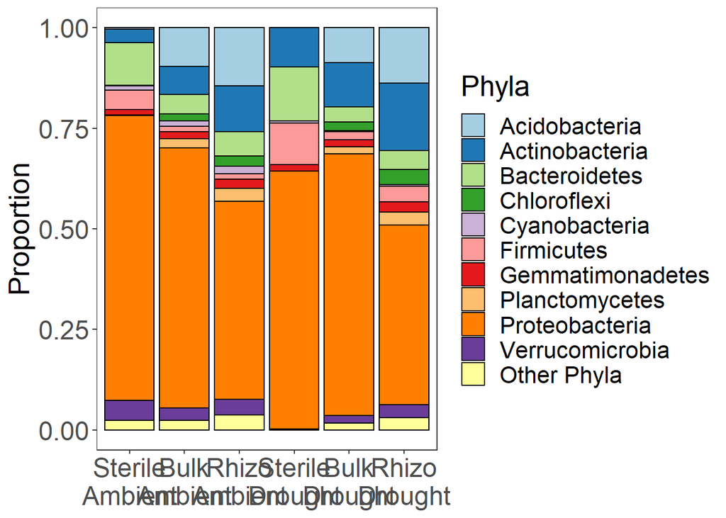

##### Combined taxon stacked bargraph

[figure not shown]

### Starting community Stack bar graphs

```
## [1] 8
```

```
## [1] "B" "R"
```

```
##  [1] "p:Deinococcus-Thermus"      "p:TM6"
##  [3] "UNKNOWN"                    "p:Acidobacteria"
##  [5] "p:Elusimicrobia"            "p:Parcubacteria"
##  [7] "p:Proteobacteria"           "p:Microgenomates"
##  [9] "p:Candidate_division_SR1"   "p:SM2F11"
## [11] "p:Gracilibacteria"          "p:WCHB1-60"
## [13] "p:Saccharibacteria"         "p:Euryarchaeota"
## [15] "p:Thaumarchaeota"           "p:Woesearchaeota_[DHVEG-6]"
## [17] "p:Omnitrophica"             "p:Cyanobacteria"
## [19] "p:Spirochaetae"             "p:Chlorobi"
## [21] "p:GOUTA4"                   "p:Bacteroidetes"
## [23] "p:Planctomycetes"           "p:Armatimonadetes"
## [25] "p:Fibrobacteres"            "p:Chloroflexi"
## [27] "p:SHA-109"                  "p:Thermotogae"
## [29] "p:Firmicutes"               "p:Tenericutes"
## [31] "p:Actinobacteria"           "p:WD272"
## [33] "p:Aerophobetes"             "p:GAL08"
## [35] "p:Latescibacteria"          "p:Nitrospirae"
## [37] "p:Candidate_division_OP3"   "p:Verrucomicrobia"
## [39] "p:Hydrogenedentes"          "p:Chlamydiae"
## [41] "p:Lentisphaerae"            "p:JL-ETNP-Z39"
## [43] "p:Gemmatimonadetes"
```

```
## phyloseq-class experiment-level object
## otu_table()   OTU Table:         [ 44 taxa and 2 samples ]
## sample_data() Sample Data:       [ 2 samples by 41 sample variables ]
## tax_table()   Taxonomy Table:    [ 44 taxa by 7 taxonomic ranks ]
## phy_tree()    Phylogenetic Tree: [ 44 tips and 43 internal nodes ]
```

```
##        B                 R
##  Min.   :0.01970   Min.   :0.01777
##  1st Qu.:0.04110   1st Qu.:0.04225
##  Median :0.05315   Median :0.05505
##  Mean   :0.09091   Mean   :0.09091
##  3rd Qu.:0.10319   3rd Qu.:0.09050
##  Max.   :0.26222   Max.   :0.27448
```

```
##        B                 R              Phylum
##  Min.   :0.01970   Min.   :0.01777   Length:11
##  1st Qu.:0.04110   1st Qu.:0.04225   Class :character
##  Median :0.05315   Median :0.05505   Mode  :character
##  Mean   :0.09091   Mean   :0.09091
##  3rd Qu.:0.10319   3rd Qu.:0.09050
##  Max.   :0.26222   Max.   :0.27448
```

```
##     Phylum          variable     value
##  Length:22          B:11     Min.   :0.01777
##  Class :character   R:11     1st Qu.:0.03886
##  Mode  :character            Median :0.05410
##                              Mean   :0.09091
##                              3rd Qu.:0.09811
##                              Max.   :0.27448
```

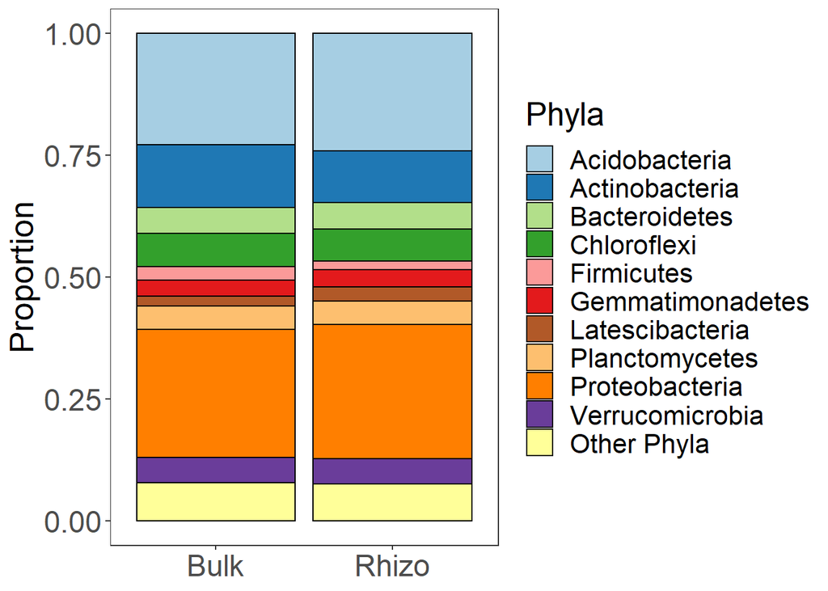

# Community Diversity

### Transplant Richness

Diagnostic Graphs

```r
bact_obs_rich_model_trans= lmer((Observed)~soil_root*precip+(1|block), data= SILVA_MERDS_rar.divfil_trt_trans)
```

```
## boundary (singular) fit: see ?isSingular
```

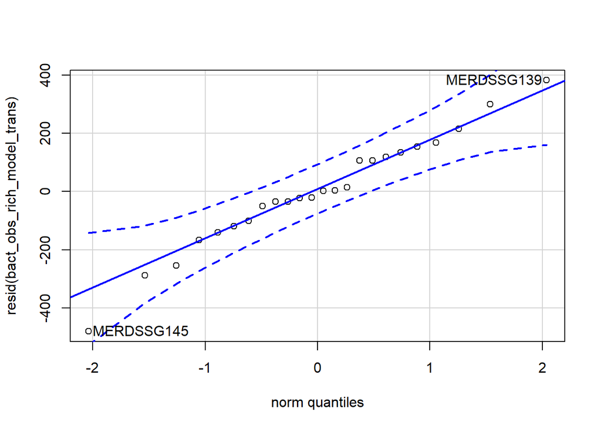

```
## MERDSSG145 MERDSSG139
##         13         11
```

```r
qqPlot(resid(bact_obs_rich_model_trans))
```

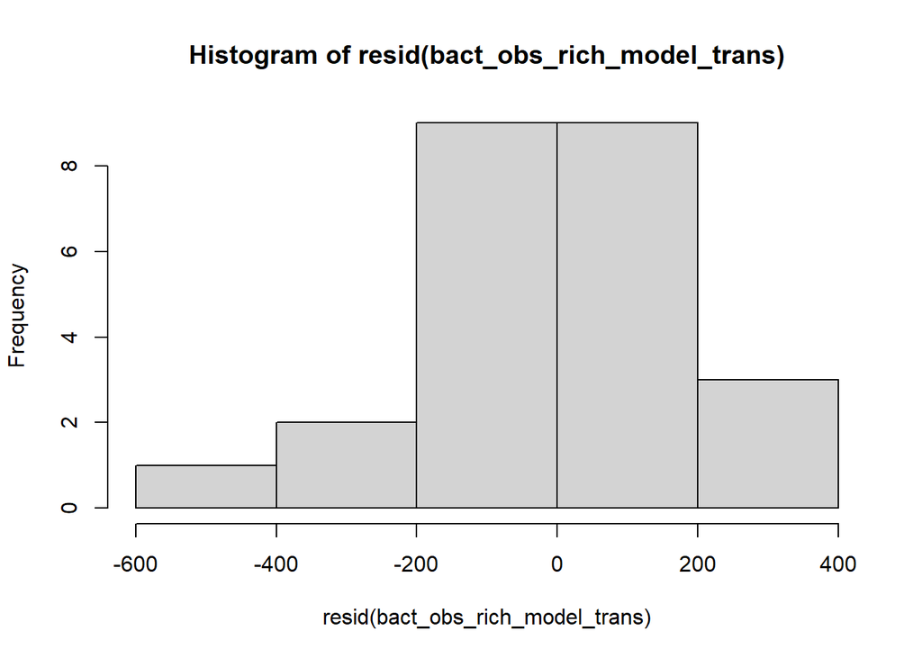

```r
hist(resid(bact_obs_rich_model_trans))
```

```r
shapiro.test(resid(bact_obs_rich_model_trans))
```

```
##
##  Shapiro-Wilk normality test
##
## data:  resid(bact_obs_rich_model_trans)
## W = 0.98049, p-value = 0.9046
```

Raw Statistical output

```r
anova(bact_obs_rich_model_trans)
```

```
## Type III Analysis of Variance Table with Satterthwaite's method
##                   Sum Sq Mean Sq NumDF DenDF F value   Pr(>F)
## soil_root        6371572 3185786     2    18 67.9823 4.08e-09 ***
## precip            234235  234235     1    18  4.9984  0.03828 *
## soil_root:precip  219760  109880     2    18  2.3448  0.12446
## ---
## Signif. codes:  0 '***' 0.001 '**' 0.01 '*' 0.05 '.' 0.1 ' ' 1
```

```r
emmeans(bact_obs_rich_model_trans, pairwise~soil_root|precip)
```

```
## Note: Use 'contrast(regrid(object), ...)' to obtain contrasts of back-transformed estimates
```

```
## $emmeans
## precip = A:
##  soil_root emmean  SE df lower.CL upper.CL
##  L.B         1368 108 18   1141.1     1596
##  S.B          242 108 18     14.6      469
##  L.R         1533 108 18   1305.9     1761
##
## precip = D:
##  soil_root emmean  SE df lower.CL upper.CL
##  L.B         1286 108 18   1058.4     1513
##  S.B          199 108 18    -28.1      427
##  L.R         1066 108 18    838.6     1293
##
## Degrees-of-freedom method: kenward-roger
## Results are given on the ( (not the response) scale.
## Confidence level used: 0.95
##
## $contrasts
## precip = A:
##  contrast  estimate  SE df t.ratio p.value
##  L.B - S.B     1126 153 15  7.359  <.0001
##  L.B - L.R     -165 153 15 -1.076  0.5426
##  S.B - L.R    -1291 153 15 -8.436  <.0001
##
## precip = D:
##  contrast  estimate  SE df t.ratio p.value
##  L.B - S.B     1086 153 15  7.098  <.0001
##  L.B - L.R      220 153 15  1.436  0.3486
##  S.B - L.R     -867 153 15 -5.662  0.0001
##
## Note: contrasts are still on the ( scale
## Degrees-of-freedom method: kenward-roger
## P value adjustment: tukey method for comparing a family of 3 estimates
```

```r
emmeans(bact_obs_rich_model_trans, pairwise~soil_root)
```

```
## NOTE: Results may be misleading due to involvement in interactions
## Note: Use 'contrast(regrid(object), ...)' to obtain contrasts of back-transformed estimates
```

```
## $emmeans
##  soil_root emmean   SE df lower.CL upper.CL
##  L.B         1327 76.5 15   1164.0     1490
##  S.B          221 76.5 15     57.5      384
##  L.R         1300 76.5 15   1136.5     1463
##
## Results are averaged over the levels of: precip
## Degrees-of-freedom method: kenward-roger
## Results are given on the ( (not the response) scale.
## Confidence level used: 0.95
##
## $contrasts
##  contrast  estimate  SE df t.ratio p.value
##  L.B - S.B   1106.5 108 15 10.223  <.0001
##  L.B - L.R     27.5 108 15  0.254  0.9651
##  S.B - L.R  -1079.0 108 15 -9.969  <.0001
##
## Results are averaged over the levels of: precip
## Note: contrasts are still on the ( scale
## Degrees-of-freedom method: kenward-roger
## P value adjustment: tukey method for comparing a family of 3 estimates
```

Formatted Anova table

Transplant soil communtiy richness

|  | Df | Resid.Df | F.value | P.value |
| --- | --- | --- | --- | --- |
| soil_root | 2 | 18 | 67.98 | 0.000 |
| precip | 1 | 18 | 5.00 | 0.038 |
| soil_root:precip | 2 | 18 | 2.34 | 0.124 |

##### Graph for publication

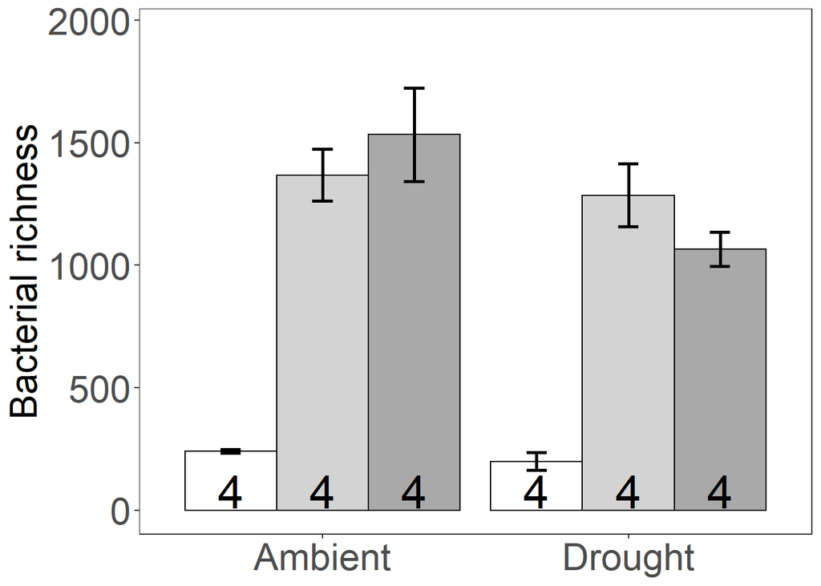

### Presence Richness

Diagnostic Graphs

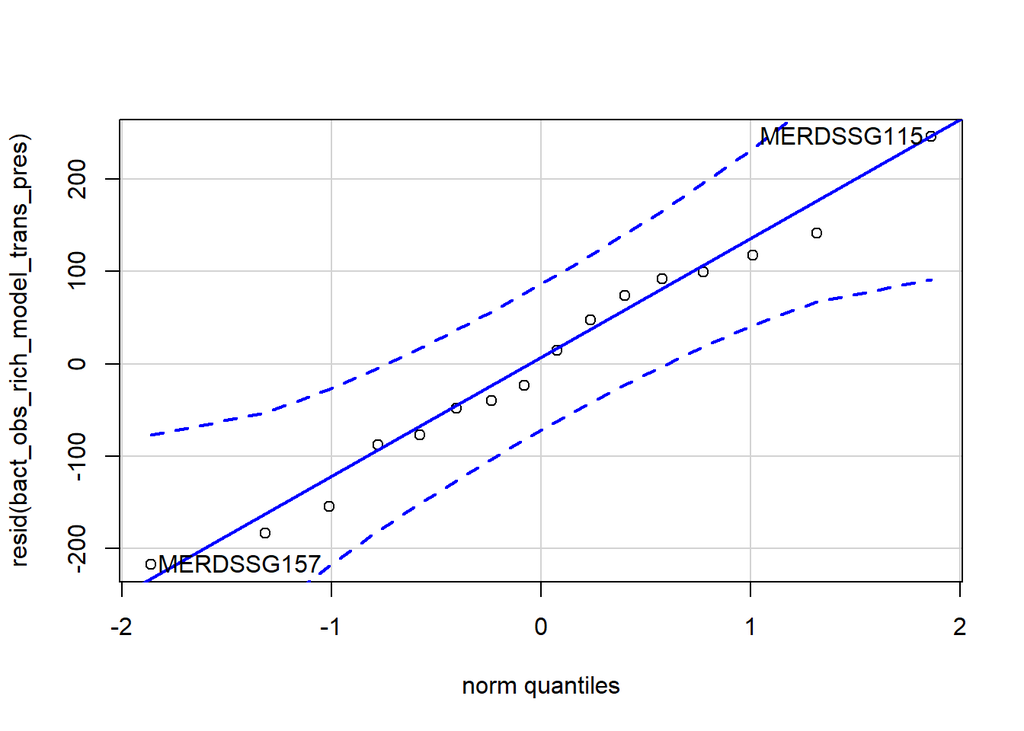

```
## MERDSSG115 MERDSSG157
##          3         10
```

```r
SILVA_MERDS_rar.divfil_pres_trans=subset(SILVA_MERDS_rar.divfil_trt_trans, root_association =="B")

bact_obs_rich_model_trans_pres= lmer((Observed)~soil_root*precip+(1|block), data= SILVA_MERDS_rar.divfil_pres_trans)
qqPlot(resid(bact_obs_rich_model_trans_pres))
```

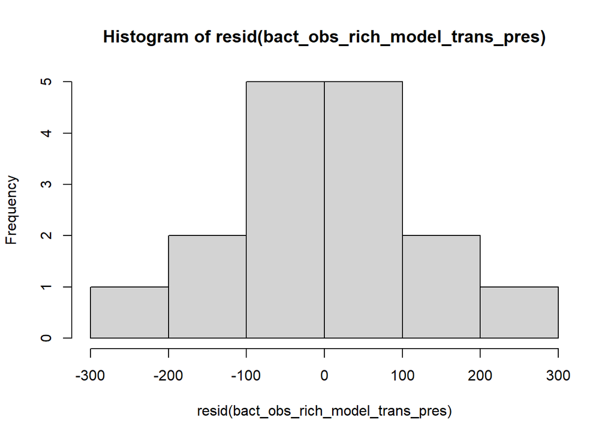

```r
hist(resid(bact_obs_rich_model_trans_pres))
```

```r
shapiro.test(resid(bact_obs_rich_model_trans_pres))
```

```
##
##  Shapiro-Wilk normality test
##
## data:  resid(bact_obs_rich_model_trans_pres)
## W = 0.98107, p-value = 0.9715
```

Raw Statistical output

```r
anova(bact_obs_rich_model_trans_pres)
```

```
## Type III Analysis of Variance Table with Satterthwaite's method
##                   Sum Sq Mean Sq NumDF DenDF  F value    Pr(>F)
## soil_root        4897369 4897369     1     9 210.6111 1.503e-07 ***
## precip             15750   15750     1     9   0.6773    0.4318
## soil_root:precip    1600    1600     1     9   0.0688    0.7990
## ---
## Signif. codes:  0 '***' 0.001 '**' 0.01 '*' 0.05 '.' 0.1 ' ' 1
```

```r
emmeans(bact_obs_rich_model_trans_pres, pairwise~soil_root|precip)
```

```
## Note: Use 'contrast(regrid(object), ...)' to obtain contrasts of back-transformed estimates
```

```
## $emmeans
## precip = A:
##  soil_root emmean   SE   df lower.CL upper.CL
##  L.B         1368 85.2 10.7   1180.4     1557
##  S.B          242 85.2 10.7     53.9      430
##
## precip = D:
##  soil_root emmean   SE   df lower.CL upper.CL
##  L.B         1286 85.2 10.7   1097.7     1474
##  S.B          199 85.2 10.7     11.2      387
##
## Degrees-of-freedom method: kenward-roger
## Results are given on the ( (not the response) scale.
## Confidence level used: 0.95
##
## $contrasts
## precip = A:
##  contrast  estimate  SE df t.ratio p.value
##  L.B - S.B     1126 108  9 10.447  <.0001
##
## precip = D:
##  contrast  estimate  SE df t.ratio p.value
##  L.B - S.B     1086 108  9 10.076  <.0001
##
## Note: contrasts are still on the ( scale
## Degrees-of-freedom method: kenward-roger
```

Formatted Anova table

Presence Transplant soil communtiy richness

|  | Df | Resid.Df | F.value | P.value |
| --- | --- | --- | --- | --- |
| soil_root | 1 | 9 | 210.61 | 0.000 |
| precip | 1 | 9 | 0.68 | 0.432 |
| soil_root:precip | 1 | 9 | 0.07 | 0.799 |

### Origin Richness

Diagnostic Graphs

```r
SILVA_MERDS_rar.divfil_orig_trans=subset(SILVA_MERDS_rar.divfil_trt_trans, soil_status =="L")

bact_obs_rich_model_trans_orig= lmer((Observed)~soil_root*precip+(1|block), data= SILVA_MERDS_rar.divfil_orig_trans)
```

```
## boundary (singular) fit: see ?isSingular
```

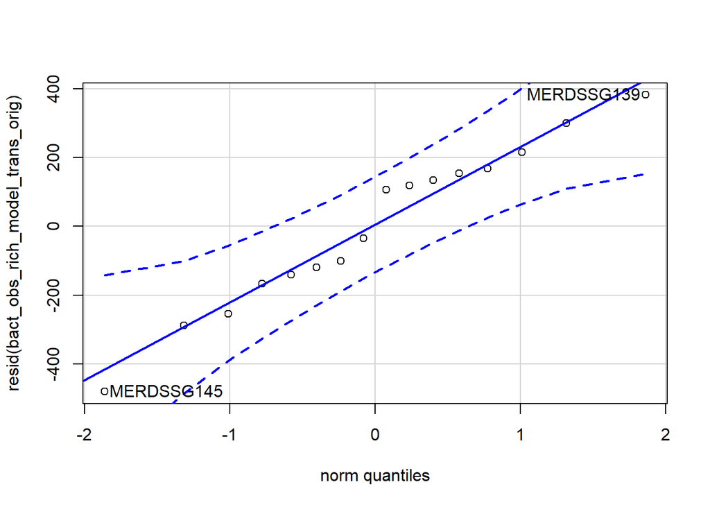

```
## MERDSSG145 MERDSSG139
##          9          7
```

```r
qqPlot(resid(bact_obs_rich_model_trans_orig))
```

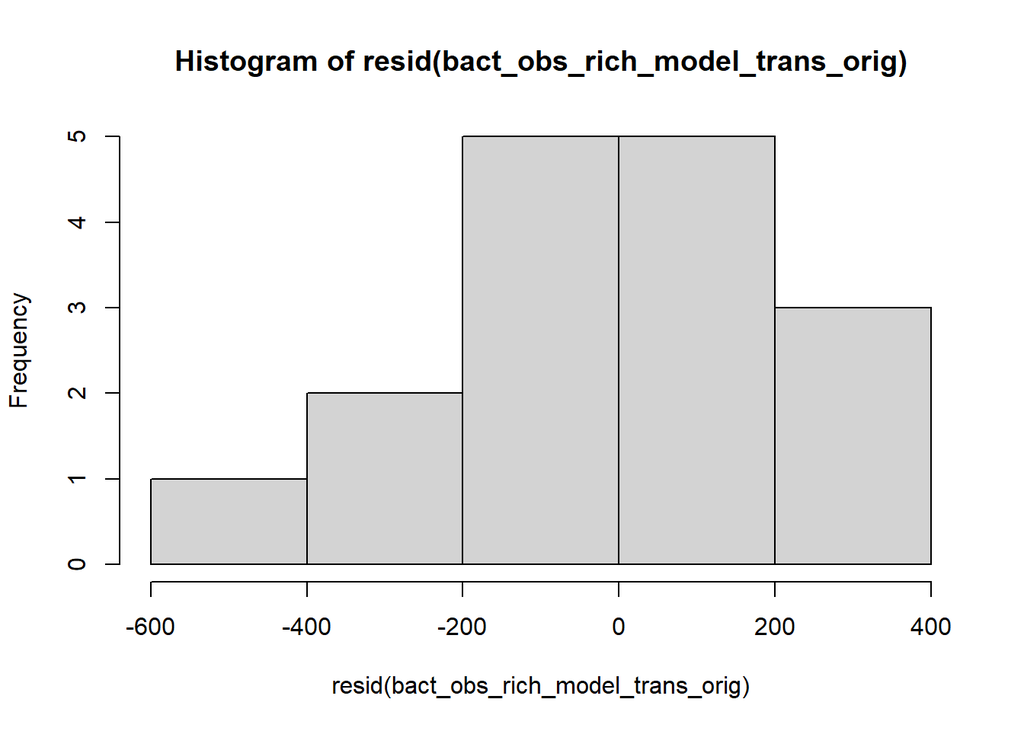

```r
hist(resid(bact_obs_rich_model_trans_orig))
```

```r
shapiro.test(resid(bact_obs_rich_model_trans_orig))
```

```
##
##  Shapiro-Wilk normality test
##
## data:  resid(bact_obs_rich_model_trans_orig)
## W = 0.96971, p-value = 0.834
```

Raw Statistical output

```r
anova(bact_obs_rich_model_trans_orig)
```

```
## Type III Analysis of Variance Table with Satterthwaite's method
##                  Sum Sq Mean Sq NumDF DenDF F value  Pr(>F)
## soil_root          3025    3025     1    12  0.0439 0.83759
## precip           302500  302500     1    12  4.3880 0.05808 .
## soil_root:precip 147840  147840     1    12  2.1445 0.16878
## ---
## Signif. codes:  0 '***' 0.001 '**' 0.01 '*' 0.05 '.' 0.1 ' ' 1
```

```r
emmeans(bact_obs_rich_model_trans_orig, pairwise~soil_root|precip)
```

```
## Note: Use 'contrast(regrid(object), ...)' to obtain contrasts of back-transformed estimates
```

```
## $emmeans
## precip = A:
##  soil_root emmean  SE df lower.CL upper.CL
##  L.B         1368 131 12     1082     1655
##  L.R         1533 131 12     1247     1819
##
## precip = D:
##  soil_root emmean  SE df lower.CL upper.CL
##  L.B         1286 131 12     1000     1572
##  L.R         1066 131 12      780     1352
##
## Degrees-of-freedom method: kenward-roger
## Results are given on the ( (not the response) scale.
## Confidence level used: 0.95
##
## $contrasts
## precip = A:
##  contrast  estimate  SE df t.ratio p.value
##  L.B - L.R     -165 186  9 -0.887  0.3980
##
## precip = D:
##  contrast  estimate  SE df t.ratio p.value
##  L.B - L.R      220 186  9  1.184  0.2669
##
## Note: contrasts are still on the ( scale
## Degrees-of-freedom method: kenward-roger
```

Formatted Anova table

|  | Df | Resid.Df | F.value | P.value |
| --- | --- | --- | --- | --- |
| soil_root | 1 | 12 | 0.04 | 0.838 |
| precip | 1 | 12 | 4.39 | 0.058 |
| soil_root:precip | 1 | 12 | 2.14 | 0.169 |

### Transplant inv Simpson

Diagnostic Graphs

```r
bact_inv_simp_model_trans= lmer((InvSimpson)~soil_root*precip+(1|block), data= SILVA_MERDS_rar.divfil_trt_trans)
```

```
## boundary (singular) fit: see ?isSingular
```

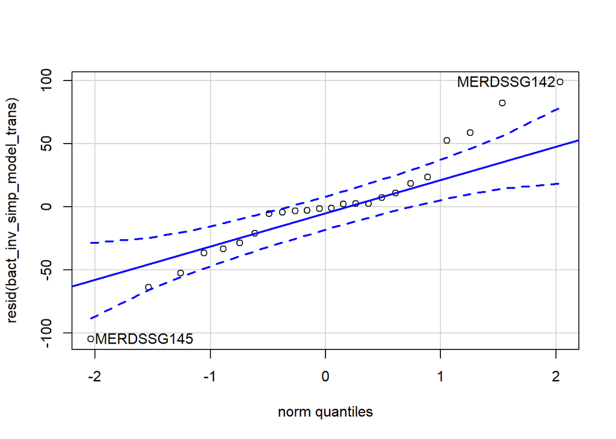

```
## MERDSSG145 MERDSSG142
##         13         12
```

```r
qqPlot(resid(bact_inv_simp_model_trans))
```

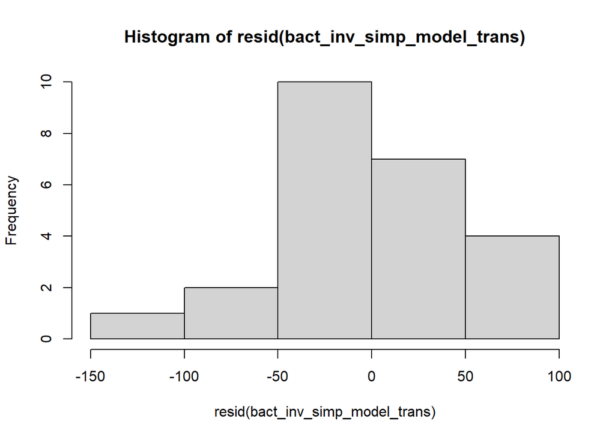

```r
hist(resid(bact_inv_simp_model_trans))
```

```r
shapiro.test(resid(bact_inv_simp_model_trans))
```

```
##
##  Shapiro-Wilk normality test
##
## data:  resid(bact_inv_simp_model_trans)
## W = 0.95212, p-value = 0.3009
```

Raw Statistical output

```r
anova(bact_inv_simp_model_trans)
```

```
## Type III Analysis of Variance Table with Satterthwaite's method
##                   Sum Sq Mean Sq NumDF DenDF F value  Pr(>F)
## soil_root        19678.6  9839.3     2    18  3.8952 0.03929 *
## precip            3523.8  3523.8     1    18  1.3950 0.25293
## soil_root:precip 14434.7  7217.3     2    18  2.8572 0.08363 .
## ---
## Signif. codes:  0 '***' 0.001 '**' 0.01 '*' 0.05 '.' 0.1 ' ' 1
```

```r
emmeans(bact_inv_simp_model_trans, pairwise~soil_root|precip)
```

```
## Note: Use 'contrast(regrid(object), ...)' to obtain contrasts of back-transformed estimates
```

```
## $emmeans
## precip = A:
##  soil_root emmean   SE df lower.CL upper.CL
##  L.B         54.2 25.1 18      1.4    107.0
##  S.B         20.8 25.1 18    -32.0     73.6
##  L.R        127.9 25.1 18     75.1    180.7
##
## precip = D:
##  soil_root emmean   SE df lower.CL upper.CL
##  L.B         81.4 25.1 18     28.6    134.2
##  S.B         11.1 25.1 18    -41.7     63.9
##  L.R         37.7 25.1 18    -15.1     90.5
##
## Degrees-of-freedom method: kenward-roger
## Results are given on the ( (not the response) scale.
## Confidence level used: 0.95
##
## $contrasts
## precip = A:
##  contrast  estimate   SE df t.ratio p.value
##  L.B - S.B     33.4 35.5 15  0.939  0.6246
##  L.B - L.R    -73.7 35.5 15 -2.074  0.1291
##  S.B - L.R   -107.1 35.5 15 -3.014  0.0224
##
## precip = D:
##  contrast  estimate   SE df t.ratio p.value
##  L.B - S.B     70.3 35.5 15  1.979  0.1517
##  L.B - L.R     43.8 35.5 15  1.231  0.4537
##  S.B - L.R    -26.6 35.5 15 -0.747  0.7398
##
## Note: contrasts are still on the ( scale
## Degrees-of-freedom method: kenward-roger
## P value adjustment: tukey method for comparing a family of 3 estimates
```

```r
emmeans(bact_inv_simp_model_trans, pairwise~soil_root)
```

```
## NOTE: Results may be misleading due to involvement in interactions
## Note: Use 'contrast(regrid(object), ...)' to obtain contrasts of back-transformed estimates
```

```
## $emmeans
##  soil_root emmean   SE df lower.CL upper.CL
##  L.B         67.8 17.8 15     29.9    105.7
##  S.B         16.0 17.8 15    -21.9     53.8
##  L.R         82.8 17.8 15     44.9    120.7
##
## Results are averaged over the levels of: precip
## Degrees-of-freedom method: kenward-roger
## Results are given on the ( (not the response) scale.
## Confidence level used: 0.95
##
## $contrasts
##  contrast  estimate   SE df t.ratio p.value
##  L.B - S.B     51.9 25.1 15  2.064  0.1314
##  L.B - L.R    -15.0 25.1 15 -0.596  0.8244
##  S.B - L.R    -66.8 25.1 15 -2.659  0.0445
##
## Results are averaged over the levels of: precip
## Note: contrasts are still on the ( scale
## Degrees-of-freedom method: kenward-roger
## P value adjustment: tukey method for comparing a family of 3 estimates
```

Formatted Anova table

Transplant soil communtiy inv Simpson

|  | Df | Resid.Df | F.value | P.value |
| --- | --- | --- | --- | --- |
| soil_root | 2 | 18 | 3.90 | 0.039 |
| precip | 1 | 18 | 1.40 | 0.253 |
| soil_root:precip | 2 | 18 | 2.86 | 0.084 |